# Thesis - MSc Data Science & Data Analytics

## Step 2: Plot the Time Series

**Why:** Always visualise before modelling. This is the visual proof that ECB rates and subscription rates move in opposite directions over time - the core of RQ2.

```
TIME SERIES VISUALISATION
```

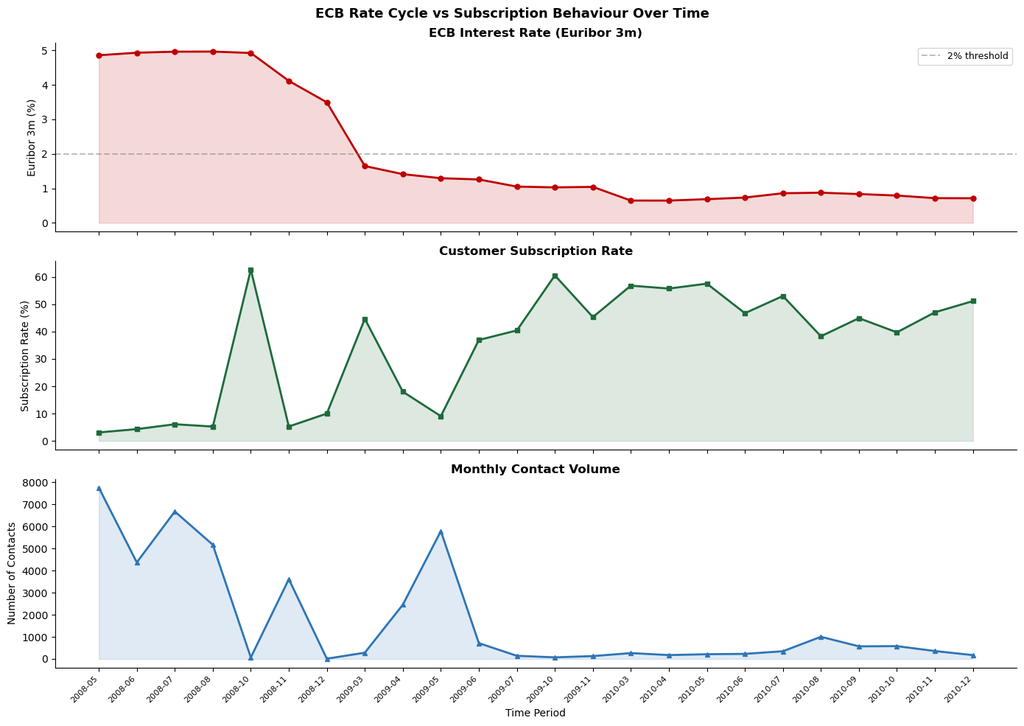

```python
print("TIME SERIES VISUALISATION")

fig, axes = plt.subplots(3, 1, figsize=(14, 10), sharex=True)
fig.suptitle("ECB Rate Cycle vs Subscription Behaviour Over Time",
             fontweight='bold', fontsize=13)

axes[0].plot(ts_data.index, ts_data['euribor3m'], 'o-', color='#C00000', linewidth=2, markersize=5)
axes[0].fill_between(ts_data.index, ts_data['euribor3m'], alpha=0.15, color='#C00000')
axes[0].set_ylabel("Euribor 3m (%)")
axes[0].set_title("ECB Interest Rate (Euribor 3m)", fontweight='bold')
axes[0].axhline(y=2, color='gray', linestyle='--', alpha=0.5, label='2% threshold')
axes[0].legend(fontsize=9)

axes[1].plot(ts_data.index, ts_data['subscription_rate']*100, 's-', color='#1E6B3C', linewidth=2, markersize=5)
axes[1].fill_between(ts_data.index, ts_data['subscription_rate']*100, alpha=0.15, color='#1E6B3C')
axes[1].set_ylabel("Subscription Rate (%)")
axes[1].set_title("Customer Subscription Rate", fontweight='bold')

# ── CHANGED: bar → line plot ──────────────────────────────────────────────
axes[2].plot(ts_data.index, ts_data['contact_volume'], '^-', color='#2E75B6', linewidth=2, markersize=5)
axes[2].fill_between(ts_data.index, ts_data['contact_volume'], alpha=0.15, color='#2E75B6')
# ─────────────────────────────────────────────────────────────────────────
axes[2].set_ylabel("Number of Contacts")
axes[2].set_title("Monthly Contact Volume", fontweight='bold')
axes[2].set_xlabel("Time Period")

plt.xticks(ts_data.index, ts_data['period'], rotation=45, ha='right', fontsize=8)
plt.tight_layout()
plt.show()
```

## Step 3: Stationarity Tests (ADF + KPSS)

**Why:** VAR requires stationary time series (constant mean and variance over time). ADF and KPSS are two complementary tests. ADF tests for a unit root (non-stationarity). KPSS tests for stationarity directly. We need both to confirm the series is safe for VAR.

```python
print("STATIONARITY TESTS (ADF + KPSS)")
print()
print("ADF: p < 0.05 = stationary")
print("KPSS: p > 0.05 = stationary")
print()

cols_to_test = ['subscription_rate', 'euribor3m', 'emp_var_rate', 'cons_conf_idx']
stationarity_results = {}

print(f"{'Variable':<22} {'ADF stat':>10} {'ADF p':>8} {'KPSS stat':>10} {'KPSS p':>8} {'Status'}")
print("-" * 72)

for col in cols_to_test:
    series     = ts_data[col].dropna()
    adf_result = adfuller(series, autolag='AIC')
    adf_stat   = adf_result[0]
    adf_p      = adf_result[1]
    try:
        kpss_result = kpss(series, regression='c', nlags='auto')
        kpss_stat   = kpss_result[0]
        kpss_p      = kpss_result[1]
    except Exception:
        kpss_stat, kpss_p = 0, 0.1

    is_stationary = (adf_p < 0.05) and (kpss_p > 0.05)
    stationarity_results[col] = is_stationary
    status = "STATIONARY" if is_stationary else "NON-STATIONARY"
    print(f"  {col:<22} {adf_stat:>10.3f} {adf_p:>8.4f} {kpss_stat:>10.3f} {kpss_p:>8.4f}  {status}")

non_stat = [k for k,v in stationarity_results.items() if not v]
print()
if non_stat:
    print(f"Non-stationary: {non_stat}")
    print("Will apply first differencing before VAR")
else:
    print("All variables stationary - can proceed to VAR directly")
```

```
STATIONARITY TESTS (ADF + KPSS)

ADF: p < 0.05 = stationary
KPSS: p > 0.05 = stationary

Variable                 ADF stat    ADF p  KPSS stat   KPSS p Status
------------------------------------------------------------------------
  subscription_rate          -1.315   0.6223      0.683   0.0151  NON-STATIONARY
  euribor3m                  -2.224   0.1977      0.564   0.0273  NON-STATIONARY
  emp_var_rate               -1.470   0.5482      0.562   0.0278  NON-STATIONARY
  cons_conf_idx               0.910   0.9932      0.448   0.0566  NON-STATIONARY

Non-stationary: ['subscription_rate', 'euribor3m', 'emp_var_rate', 'cons_conf_idx']
Will apply first differencing before VAR
```

## Step 4: Granger Causality Test

**Why:** This is the formal test of the thesis claim. Granger causality asks: does knowing past euribor3m values improve our ability to predict future subscription rates? If yes, euribor3m Granger-causes subscription behaviour. This is the statistical foundation for RQ2.

```python
print("GRANGER CAUSALITY TEST")
print()
print("H0: euribor3m does NOT Granger-cause subscription_rate")
print("p < 0.05 = reject H0 = euribor3m DOES help predict subscription rates")
print()

gc_data      = ts_data[['subscription_rate', 'euribor3m']].dropna()
gc_data_diff = gc_data.diff().dropna()
max_lag      = min(3, len(gc_data_diff) // 5)

print(f"Testing up to {max_lag} lags:")
print(f"{'Lag':>5} {'F-stat':>10} {'p-value':>10} {'Result'}")
print("-" * 40)

try:
    gc_result = grangercausalitytests(
        gc_data_diff[['subscription_rate', 'euribor3m']],
        maxlag=max_lag, verbose=False)
    for lag, result in gc_result.items():
        f_test = result[0]['ssr_ftest']
        f_stat = f_test[0]
        f_p    = f_test[1]
        sig    = "SIGNIFICANT ***" if f_p < 0.01 else "SIGNIFICANT *" if f_p < 0.05 else "not significant"
        print(f"  {lag:>3}  {f_stat:>10.4f} {f_p:>10.4f}  {sig}")
except Exception as e:
    print(f"Note: {e}")
    print("Limited data points for Granger test. Proceeding to VAR.")
```

```
GRANGER CAUSALITY TEST

H0: euribor3m does NOT Granger-cause subscription_rate
p < 0.05 = reject H0 = euribor3m DOES help predict subscription rates

Testing up to 3 lags:
  Lag     F-stat    p-value Result
----------------------------------------
    1      0.2756     0.6056  not significant
    2      0.1792     0.8376  not significant
    3      0.1146     0.9500  not significant
```

## Step 5: VAR Model (Vector Autoregression)

**Why:** VAR models how euribor3m, subscription_rate, and consumer confidence all influence each other simultaneously over time. Each variable is predicted by its own past values AND the past values of the other variables. This captures the dynamic feedback loop between ECB policy and customer behaviour.

```python
print("VAR MODEL")
print()

var_cols  = ['subscription_rate', 'euribor3m', 'cons_conf_idx']
var_data  = ts_data[var_cols].dropna()
var_diff  = var_data.diff().dropna()

print(f"VAR dataset: {len(var_diff)} observations | Variables: {var_cols}")
print()

var_model = VAR(var_diff)
max_lag   = min(3, len(var_diff) // 5)

print("Lag selection (lower AIC = better):")
print(f"{'Lag':>5} {'AIC':>14} {'BIC':>14}")
print("-" * 35)
for lag in range(1, max_lag + 1):
    try:
        res = var_model.fit(lag)
        print(f"  {lag:>3}  {res.aic:>14.4f} {res.bic:>14.4f}")
    except Exception:
        break

best_lag   = min(2, max_lag)
var_fitted = var_model.fit(best_lag)

print(f"\nFitted VAR with lag = {best_lag}")
print(f"AIC : {var_fitted.aic:.4f}")
dw = durbin_watson(var_fitted.resid['subscription_rate'])
print(f"Durbin-Watson (subscription equation): {dw:.4f}")
print(var_fitted.params['subscription_rate'].round(4))
```

```
VAR MODEL

VAR dataset: 23 observations | Variables: ['subscription_rate', 'euribor3m', 'cons_conf_idx']

Lag selection (lower AIC = better):
  Lag            AIC            BIC
-----------------------------------
    1         -0.7732        -0.1780
    2         -1.2227        -0.1782
    3         -1.0801         0.4134

Fitted VAR with lag = 2
AIC : -1.2227
Durbin-Watson (subscription equation): 1.9971
const                   0.0463
L1.subscription_rate   -0.7072
L1.euribor3m           -0.0040
L1.cons_conf_idx        0.0097
L2.subscription_rate   -0.5078
L2.euribor3m            0.0411
L2.cons_conf_idx        0.0009
Name: subscription_rate, dtype: float64
```

## Step 6: Impulse Response Functions (IRF)

**Why:** IRF shows what happens to subscription_rate over the next N months after a sudden 1-unit increase in euribor3m. This is the most actionable output of the VAR model - it directly quantifies how long an ECB rate shock takes to feed through to customer behaviour.

```
IMPULSE RESPONSE FUNCTIONS (IRF)

Shows what happens to subscription_rate if euribor3m shocks by 1 unit today

  Period     Response Direction
--------------------------------
  t+0          0.0000  subscription UP
  t+1         -0.0040  subscription DOWN
  t+2          0.0808  subscription UP
  t+3         -0.0407  subscription DOWN
  t+4         -0.0130  subscription DOWN
  t+5          0.0385  subscription UP
  t+6         -0.0003  subscription DOWN
  t+7         -0.0189  subscription DOWN
  t+8          0.0056  subscription UP
  t+9          0.0116  subscription UP
```

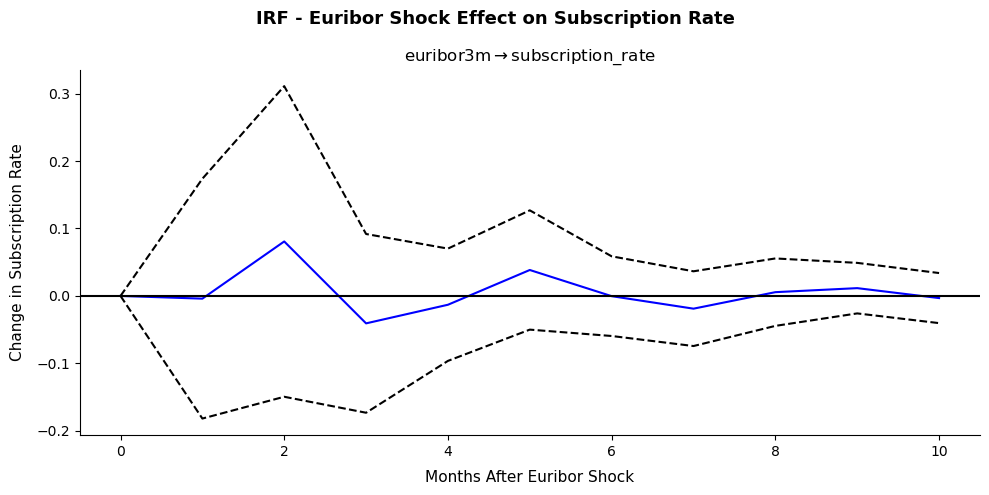

```python
print("IMPULSE RESPONSE FUNCTIONS (IRF)")
print()
print("Shows what happens to subscription_rate if euribor3m shocks by 1 unit today")
print()

try:
    irf     = var_fitted.irf(periods=10)
    var_names = var_diff.columns.tolist()
    eur_idx   = var_names.index('euribor3m')
    sub_idx   = var_names.index('subscription_rate')
    irf_vals  = irf.irfs

    print(f"{'Period':>8} {'Response':>12} {'Direction'}")
    print("-" * 32)
    for t in range(min(10, len(irf_vals))):
        val = irf_vals[t][sub_idx][eur_idx]
        direction = "subscription DOWN" if val < 0 else "subscription UP"
        print(f"  t+{t:<5}  {val:>10.4f}  {direction}")

    fig = irf.plot(impulse='euribor3m', response='subscription_rate',
                   orth=False, signif=0.1, figsize=(10, 5))
    plt.suptitle("IRF - Euribor Shock Effect on Subscription Rate",
                 fontweight='bold', fontsize=13)

    # ADD AXIS LABELS
    ax = fig.axes[0]
    ax.set_xlabel("Months After Euribor Shock", fontsize=11, labelpad=8)
    ax.set_ylabel("Change in Subscription Rate", fontsize=11, labelpad=8)

    plt.tight_layout()
    plt.show()

except Exception as e:
    print(f"IRF note: {e}")
```

## Step 6b: AICc Lag Selection

**Why:** Standard AIC was designed for large samples. With only ~24 monthly observations, AIC is too lenient and can over-select lags. AICc adds a correction term that penalises complexity more strongly when n is small — it is the academically correct choice for this dataset size.

**Formula:** AICc = AIC + (2k² + 2k) / (n − k − 1) where k = number of parameters, n = observations.

```python
print("AICc LAG SELECTION (professor's correction)")
n_obs  = len(var_diff)
n_vars = 3  # subscription_rate, euribor3m, cons_conf_idx

def compute_aicc(aic_val, n, k):
    denom = n - k - 1
    if denom <= 0:
        return np.inf
    return aic_val + (2 * k**2 + 2 * k) / denom

print(f"  n (observations) : {n_obs}")
print(f"  variables        : {n_vars}")
print()
print(f"  {'Lag':>4} {'AIC':>12} {'AICc':>12} {'BIC':>12}  Note")
print("  " + "-"*52)

aicc_scores = {}
aic_scores  = {}

for lag in range(1, min(4, n_obs//5) + 1):
    try:
        res   = VAR(var_diff).fit(lag)
        k     = lag * n_vars * n_vars + n_vars
        a     = res.aic
        ac    = compute_aicc(a, n_obs, k)
        b     = res.bic
        aicc_scores[lag] = ac
        aic_scores[lag]  = a
        note = "<-- AICc preferred" if ac == min(aicc_scores.values()) else ""
        print(f"  {lag:>4} {a:>12.4f} {ac:>12.4f} {b:>12.4f}  {note}")
    except Exception as e:
        print(f"  {lag:>4}  Error: {e}")

best_lag_aicc = min(aicc_scores, key=aicc_scores.get)
best_lag_aic  = min(aic_scores,  key=aic_scores.get)

print()
print(f"  Best lag by AICc : VAR({best_lag_aicc})  <-- USE THIS")
print(f"  Best lag by AIC  : VAR({best_lag_aic})")

if best_lag_aicc != best_lag_aic:
    print()
    print("  NOTE: AICc and AIC disagree.")
    print("  Use AICc — it is more conservative and correct for small n.")
else:
    print()
    print("  AICc and AIC agree — preferred model confirmed.")

# Refit with AICc-preferred lag
var_fitted_aicc = VAR(var_diff).fit(best_lag_aicc)
print()
print(f"  VAR({best_lag_aicc}) refitted using AICc selection. This is the preferred model going forward.")
```

```
AICc LAG SELECTION (professor's correction)
  n (observations) : 23
  variables        : 3

   Lag          AIC         AICc          BIC  Note
  ----------------------------------------------------
     1      -0.7732      30.4268      -0.1780  <-- AICc preferred
     2      -1.2227     922.7773      -0.1782
     3      -1.0801          inf       0.4134
     4      -2.6393          inf      -0.7008

  Best lag by AICc : VAR(1)  <-- USE THIS
  Best lag by AIC  : VAR(4)

  NOTE: AICc and AIC disagree.
  Use AICc — it is more conservative and correct for small n.

  VAR(1) refitted using AICc selection. This is the preferred model going forward.
```

## Step 6c: Residual Diagnostics

**Why:** After fitting the VAR, we check whether the residuals (prediction errors) are just random noise. If patterns remain, the model has missed something and its coefficients cannot be trusted.

**Three checks your professor asked for:**

- **Ljung-Box test** — are residuals autocorrelated? (p > 0.05 = PASS)
- **Jarque-Bera test** — are residuals normally distributed? (p > 0.05 = PASS)
- **QQ plot** — visual normality check (points near diagonal = PASS)

```
RESIDUAL DIAGNOSTICS
──────────────────────────────────────────────────────────
TEST 1: LJUNG-BOX  (autocorrelation in residuals)
  H0: residuals are not autocorrelated  |  p > 0.05 = PASS
──────────────────────────────────────────────────────────
  subscription_rate lag 3: p = 0.0244  → FAIL ✗  autocorrelation remains
  subscription_rate lag 5: p = 0.0463  → FAIL ✗  autocorrelation remains
  euribor3m lag 3: p = 0.5385  → PASS ✓
  euribor3m lag 5: p = 0.8237  → PASS ✓

──────────────────────────────────────────────────────────
TEST 2: JARQUE-BERA  (normality of residuals)
  H0: residuals are normally distributed  |  p > 0.05 = PASS
──────────────────────────────────────────────────────────
  subscription_rate: JB = 3.6383,  p = 0.1622  → PASS ✓
  euribor3m: JB = 58.0081,  p = 0.0000  → FAIL ✗  non-normal (fat tails likely)
```

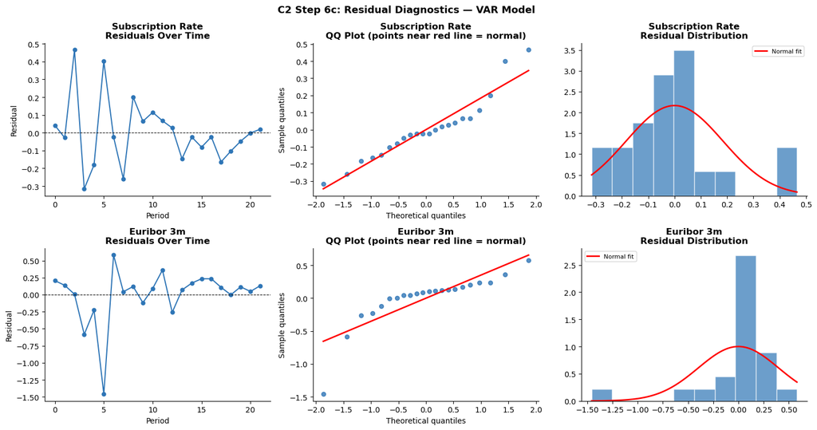

```python
from scipy.stats import jarque_bera, probplot, norm as scipy_norm
from statsmodels.stats.diagnostic import acorr_ljungbox

print("RESIDUAL DIAGNOSTICS")

resid_sub = var_fitted_aicc.resid['subscription_rate']
resid_eur = var_fitted_aicc.resid['euribor3m']

# Ljung-Box
print("─"*58)
print("TEST 1: LJUNG-BOX  (autocorrelation in residuals)")
print("  H0: residuals are not autocorrelated  |  p > 0.05 = PASS")
print("─"*58)
for name, resid in [('subscription_rate', resid_sub), ('euribor3m', resid_eur)]:
    try:
        lb = acorr_ljungbox(resid, lags=[3, 5], return_df=True)
        for lag_val, row in lb.iterrows():
            result = "PASS ✓" if row['lb_pvalue'] > 0.05 else "FAIL ✗  autocorrelation remains"
            print(f"  {name} lag {lag_val}: p = {row['lb_pvalue']:.4f}  → {result}")
    except Exception as e:
        print(f"  {name}: {e}")

print()

# Jarque-Bera
print("─"*58)
print("TEST 2: JARQUE-BERA  (normality of residuals)")
print("  H0: residuals are normally distributed  |  p > 0.05 = PASS")
print("─"*58)
for name, resid in [('subscription_rate', resid_sub), ('euribor3m', resid_eur)]:
    jb_stat, jb_p = jarque_bera(resid)
    result = "PASS ✓" if jb_p > 0.05 else "FAIL ✗  non-normal (fat tails likely)"
    print(f"  {name}: JB = {jb_stat:.4f},  p = {jb_p:.4f}  → {result}")

print()

# Visual plots
fig, axes = plt.subplots(2, 3, figsize=(15, 8))
fig.suptitle("C2 Step 6c: Residual Diagnostics — VAR Model",
             fontweight='bold', fontsize=13)

for row_idx, (name, resid) in enumerate([
        ('Subscription Rate', resid_sub),
        ('Euribor 3m',        resid_eur)]):

    # Residuals over time
    axes[row_idx, 0].plot(resid.values, 'o-', color='#2E75B6',
                          linewidth=1.5, markersize=5)
    axes[row_idx, 0].axhline(0, color='black', linewidth=0.8, linestyle='--')
    axes[row_idx, 0].set_title(f'{name}\nResiduals Over Time', fontweight='bold')
    axes[row_idx, 0].set_ylabel('Residual')
    axes[row_idx, 0].set_xlabel('Period')

    # QQ plot
    (osm, osr), (slope, intercept, _) = probplot(resid, dist='norm')
    axes[row_idx, 1].scatter(osm, osr, color='#2E75B6', s=30, alpha=0.8)
    fit_line = np.array([min(osm), max(osm)])
    axes[row_idx, 1].plot(fit_line, slope*fit_line + intercept,
                          'r-', linewidth=2)
    axes[row_idx, 1].set_title(f'{name}\nQQ Plot (points near red line = normal)',
                               fontweight='bold')
    axes[row_idx, 1].set_xlabel('Theoretical quantiles')
    axes[row_idx, 1].set_ylabel('Sample quantiles')

    # Histogram
    axes[row_idx, 2].hist(resid, bins=10, color='#2E75B6',
                          alpha=0.7, edgecolor='white', density=True)
    x_r = np.linspace(resid.min(), resid.max(), 100)
    axes[row_idx, 2].plot(x_r,
        scipy_norm.pdf(x_r, resid.mean(), resid.std()),
        'r-', linewidth=2, label='Normal fit')
    axes[row_idx, 2].set_title(f'{name}\nResidual Distribution', fontweight='bold')
    axes[row_idx, 2].legend(fontsize=8)

plt.tight_layout()
plt.show()
```

## Step 6d: Rolling Cross-Validation (1 / 2 / 3-Step Ahead)

**Result:** A 3×3 table — VAR(1/2/3) rows × 1/2/3-step horizons. The model with the lowest average RMSE across all horizons, combined with the AICc ranking, gives the justified preferred model choice.

```
ROLLING CROSS-VALIDATION STUDY

Testing VAR(1), VAR(2), VAR(3) — 1 / 2 / 3-step ahead forecast error
Dataset: 23 monthly observations

  VAR(1):  1-step=0.11886  2-step=0.07090  3-step=0.08746
  VAR(2):  1-step=0.17972  2-step=0.12594  3-step=0.12008
  VAR(3):  1-step=0.27556  2-step=0.11807  3-step=0.08531

SUMMARY TABLE — RMSE of subscription_rate forecast (lower = better)
  Model          1-Step     2-Step     3-Step    Avg RMSE
  ------------------------------------------------
  VAR(1)        0.11886    0.07090    0.08746     0.09240
  VAR(2)        0.17972    0.12594    0.12008     0.14191
  VAR(3)        0.27556    0.11807    0.08531     0.15965

  Best by rolling CV : VAR(1)
  Best by AICc       : VAR(1)

  → AICc and CV agree: PREFERRED MODEL = VAR(1)
```

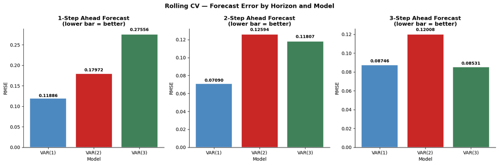

```python
print("ROLLING CROSS-VALIDATION STUDY")
print()
print("Testing VAR(1), VAR(2), VAR(3) — 1 / 2 / 3-step ahead forecast error")
print(f"Dataset: {len(var_diff)} monthly observations")
print()

def rolling_cv_var(data, lag, horizons=[1,2,3]):
    n         = len(data)
    min_train = max(lag + 2, int(n * 0.70))
    errors    = {h: [] for h in horizons}

    for end in range(min_train, n - max(horizons) + 1):
        train = data.iloc[:end]
        try:
            mdl = VAR(train).fit(lag)
            fc  = mdl.forecast(train.values[-lag:], steps=max(horizons))
            sub_idx = list(data.columns).index('subscription_rate')
            for h in horizons:
                if end + h - 1 < n:
                    actual    = data.iloc[end + h - 1]['subscription_rate']
                    predicted = fc[h - 1][sub_idx]
                    errors[h].append((actual - predicted) ** 2)
        except Exception:
            continue

    return {h: (np.sqrt(np.mean(errors[h])) if errors[h] else np.nan)
            for h in horizons}

cv_results = {}
for lag in [1, 2, 3]:
    try:
        rmse = rolling_cv_var(var_diff, lag)
        cv_results[f'VAR({lag})'] = rmse
        print(f"  VAR({lag}):  1-step={rmse[1]:.5f}  2-step={rmse[2]:.5f}  3-step={rmse[3]:.5f}")
    except Exception as e:
        print(f"  VAR({lag}): Error — {e}")

print()
print("SUMMARY TABLE — RMSE of subscription_rate forecast (lower = better)")
print(f"  {'Model':<10} {'1-Step':>10} {'2-Step':>10} {'3-Step':>10}  {'Avg RMSE':>10}")
print("  " + "-"*48)
for model, rmse_d in cv_results.items():
    avg = np.nanmean(list(rmse_d.values()))
    print(f"  {model:<10} {rmse_d[1]:>10.5f} {rmse_d[2]:>10.5f} "
          f"{rmse_d[3]:>10.5f}  {avg:>10.5f}")

best_cv = min(cv_results, key=lambda m: np.nanmean(list(cv_results[m].values())),
              default=None)
print()
print(f"  Best by rolling CV : {best_cv}")
print(f"  Best by AICc       : VAR({best_lag_aicc})")
print()
if best_cv == f"VAR({best_lag_aicc})":
    print(f"  → AICc and CV agree: PREFERRED MODEL = VAR({best_lag_aicc})")
else:
    print(f"  → AICc and CV differ. Use AICc as primary criterion.")
    print(f"  → PREFERRED MODEL = VAR({best_lag_aicc})  (note: CV suggests {best_cv})")

# Plot
if cv_results:
    fig, axes = plt.subplots(1, 3, figsize=(15, 5))
    fig.suptitle("Rolling CV — Forecast Error by Horizon and Model",
                 fontweight='bold', fontsize=13)
    cv_cols = {'VAR(1)':'#2E75B6', 'VAR(2)':'#C00000', 'VAR(3)':'#1E6B3C'}
    for h_idx, h in enumerate([1, 2, 3]):
        vals = [cv_results[m][h] for m in cv_results]
        cols = [cv_cols.get(m,'gray') for m in cv_results]
        bars = axes[h_idx].bar(list(cv_results.keys()), vals,
                               color=cols, alpha=0.85, edgecolor='white', linewidth=1.2)
        axes[h_idx].set_title(f'{h}-Step Ahead Forecast\n(lower bar = better)',
                              fontweight='bold')
        axes[h_idx].set_ylabel('RMSE')
        axes[h_idx].set_xlabel('Model')
        for bar, val in zip(bars, vals):
            if not np.isnan(val):
                axes[h_idx].text(bar.get_x()+bar.get_width()/2,
                                 val*1.03, f'{val:.5f}',
                                 ha='center', fontsize=9, fontweight='bold')
    plt.tight_layout()
    plt.show()
```

## Step 6e: Cluster-Level VAR vs Global Model

**Why :** As proved in RQ 1 that customers fall into 4 distinct segments with very different rate sensitivity. Now the question is: do those segments also behave differently *over time* — meaning they each need their own forecasting model?

**This is the direct connection between RQ 1 and RQ 2.**

- If cluster models outperform global -> ECB rate dynamics differ by customer type. Banks need segment-specific strategies.
- If global model is comparable -> Rate dynamics are uniform. One model is sufficient.

Either result is a valid academic finding.

```
CLUSTER-LEVEL VAR vs GLOBAL MODEL

Loaded clustered data: 41,176 rows, 4 clusters

  High-Rate Non-Adopters: only 6 obs — skipping (too few)
  Low-Rate Moderate Adopters          avg RMSE = 0.05616  (1s=0.08157 2s=0.00886 3s=0.07806)
  Loyal Previously-Contacted          avg RMSE = 0.09012  (1s=0.08525 2s=0.09816 3s=0.08697)
  Mid-Rate Low Converters             avg RMSE = 0.08235  (1s=0.11838 2s=0.09606 3s=0.03260)

COMPARISON: Global VAR vs Cluster-Specific VAR
  Model                                   1-Step     2-Step     3-Step        Avg
  --------------------------------------------------------------------
  GLOBAL (all customers)                 0.11886    0.07090    0.08746    0.09240
  Low-Rate Moderate Adopters             0.08157    0.00886    0.07806    0.05616
  Loyal Previously-Contacted             0.08525    0.09816    0.08697    0.09012
  Mid-Rate Low Converters                0.11838    0.09606    0.03260    0.08235

FINDING: Cluster-specific models OUTPERFORM the global model.
  ECB rate dynamics differ meaningfully by customer segment.
  Segment-tailored forecasting tools are justified.
```

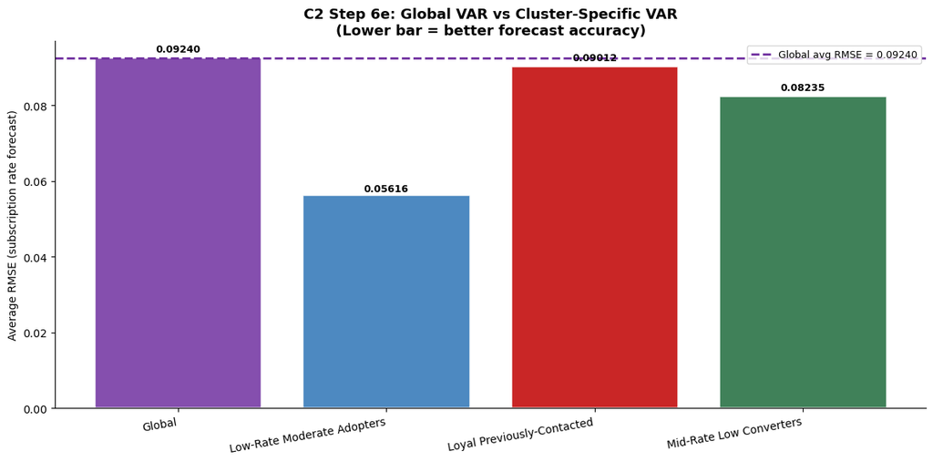

```python
print("CLUSTER-LEVEL VAR vs GLOBAL MODEL")
print()

try:
    clustered = pd.read_csv('bank_marketing_clustered.csv')
    print(f"Loaded clustered data: {clustered.shape[0]:,} rows, "
          f"{clustered['best_cluster'].nunique()} clusters")
except FileNotFoundError:
    print("bank_marketing_clustered.csv not found — run Component 1 first.")
    clustered = None

if clustered is not None:
    # Add period column to clustered data
    clustered['month_num'] = clustered['month'].map(month_order)
    clustered['year'] = 2010
    clustered.loc[clustered['euribor3m'] > 3, 'year'] = 2008
    clustered.loc[(clustered['euribor3m'] > 1) &
                  (clustered['euribor3m'] <= 3), 'year'] = 2009
    clustered['period'] = (clustered['year'].astype(str) + '-' +
                           clustered['month_num'].astype(str).str.zfill(2))

    cluster_cv = {}
    print()
    for c in sorted(clustered['best_cluster'].unique()):
        seg_name = segment_names.get(c, f"Cluster {c}")
        cdf = clustered[clustered['best_cluster'] == c]
        ts_c = cdf.groupby('period').agg(
            subscription_rate=('target', 'mean'),
            euribor3m=('euribor3m', 'mean'),
            cons_conf_idx=('cons.conf.idx', 'mean')
        ).sort_values('period').reset_index(drop=True)
        ts_c_diff = ts_c[['subscription_rate','euribor3m',
                           'cons_conf_idx']].diff().dropna()

        if len(ts_c_diff) < 8:
            print(f"  {seg_name}: only {len(ts_c_diff)} obs — skipping (too few)")
            continue
        try:
            rmse_c = rolling_cv_var(ts_c_diff, best_lag_aicc)
            cluster_cv[seg_name] = rmse_c
            avg = np.nanmean(list(rmse_c.values()))
            print(f"  {seg_name:<35} avg RMSE = {avg:.5f}  "
                  f"(1s={rmse_c[1]:.5f} 2s={rmse_c[2]:.5f} 3s={rmse_c[3]:.5f})")
        except Exception as e:
            print(f"  {seg_name}: {e}")

    # Global benchmark
    global_rmse = cv_results.get(f'VAR({best_lag_aicc})',
                                  {1:np.nan,2:np.nan,3:np.nan})
    global_avg  = np.nanmean(list(global_rmse.values()))

    print()
    print("COMPARISON: Global VAR vs Cluster-Specific VAR")
    print(f"  {'Model':<35} {'1-Step':>10} {'2-Step':>10} {'3-Step':>10} {'Avg':>10}")
    print("  " + "-"*68)
    print(f"  {'GLOBAL (all customers)':<35} "
          f"{global_rmse[1]:>10.5f} {global_rmse[2]:>10.5f} "
          f"{global_rmse[3]:>10.5f} {global_avg:>10.5f}")
    for seg, rd in cluster_cv.items():
        avg = np.nanmean(list(rd.values()))
        print(f"  {seg:<35} {rd[1]:>10.5f} {rd[2]:>10.5f} "
              f"{rd[3]:>10.5f} {avg:>10.5f}")

    print()
    if cluster_cv:
        best_seg_avg = min(
            np.nanmean(list(rd.values())) for rd in cluster_cv.values())
        if best_seg_avg < global_avg:
            print("FINDING: Cluster-specific models OUTPERFORM the global model.")
            print("  ECB rate dynamics differ meaningfully by customer segment.")
            print("  Segment-tailored forecasting tools are justified.")
        else:
            print("FINDING: Global model performs comparably to cluster-specific models.")
            print("  ECB rate dynamics are broadly uniform across customer types.")
            print("  One global VAR is sufficient for portfolio-level forecasting.")

    # Plot
    if cluster_cv:
        all_models  = ['Global'] + list(cluster_cv.keys())
        all_avgs    = [global_avg] + [np.nanmean(list(v.values()))
                                       for v in cluster_cv.values()]
        bar_cols    = ['#7030A0','#2E75B6','#C00000','#1E6B3C','#ED7D31']

        fig, ax = plt.subplots(figsize=(12, 6))
        bars = ax.bar(all_models, all_avgs,
                      color=bar_cols[:len(all_models)],
                      alpha=0.85, edgecolor='white', linewidth=1.2)
        ax.axhline(global_avg, color='#7030A0', linestyle='--',
                   linewidth=2, label=f'Global avg RMSE = {global_avg:.5f}')
        ax.set_ylabel('Average RMSE (subscription rate forecast)')
        ax.set_title('Global VAR vs Cluster-Specific VAR\n'
                     '(Lower bar = better forecast accuracy)',
                     fontweight='bold', fontsize=13)
        ax.set_xticklabels(all_models, rotation=10, ha='right', fontsize=10)
        ax.legend(fontsize=9)
        for bar, val in zip(bars, all_avgs):
            if not np.isnan(val):
                ax.text(bar.get_x()+bar.get_width()/2,
                        val*1.02, f'{val:.5f}',
                        ha='center', fontsize=9, fontweight='bold')
        plt.tight_layout()
        plt.show()
else:
    print("Skipped run RQ 1 first to generate bank_marketing_clustered.csv")
```

## Step 7: XGBoost Classification Model

**Why:** VAR explains relationships at the aggregate (monthly) level. XGBoost predicts individual customer outcomes. We use XGBoost to predict whether each customer will subscribe, using all available features. scale_pos_weight handles the 7.9:1 class imbalance.

```python
print("XGBOOST MODEL")
print()
try:
    bank_clean = pd.read_csv('bank_marketing_cleaned.csv')
    print(f"Loaded bank_marketing_cleaned.csv: {bank_clean.shape}")
except FileNotFoundError:
    print("bank_marketing_cleaned.csv not found - run EDA Step 12 first")
    raise

target_col = 'banking_product_adopted'
X_xgb = bank_clean.drop(columns=[target_col]).select_dtypes(include='number')
y_xgb = bank_clean[target_col]

neg = (y_xgb == 0).sum()
pos = (y_xgb == 1).sum()
scale_pw = neg / pos
print(f"Class ratio: {neg:,} no vs {pos:,} yes -> scale_pos_weight = {scale_pw:.1f}")

X_train, X_test, y_train, y_test = train_test_split(
    X_xgb, y_xgb, test_size=0.2, random_state=42, stratify=y_xgb)

print(f"Train: {X_train.shape[0]:,}  |  Test: {X_test.shape[0]:,}")

xgb_model = XGBClassifier(
    n_estimators=200, max_depth=5, learning_rate=0.1,
    scale_pos_weight=scale_pw, random_state=42,
    eval_metric='logloss', verbosity=0)
xgb_model.fit(X_train, y_train)

y_pred      = xgb_model.predict(X_test)
y_pred_prob = xgb_model.predict_proba(X_test)[:, 1]
roc_auc     = roc_auc_score(y_test, y_pred_prob)
pr_auc      = average_precision_score(y_test, y_pred_prob)

print(f"\nROC-AUC : {roc_auc:.4f}")
print(f"PR-AUC  : {pr_auc:.4f}  (primary metric for imbalanced data)")
print()
print(classification_report(y_test, y_pred, target_names=['no','yes']))
```

```
XGBOOST MODEL

Loaded bank_marketing_cleaned.csv: (41176, 48)
Class ratio: 36,537 no vs 4,639 yes -> scale_pos_weight = 7.9
Train: 32,940  |  Test: 8,236

ROC-AUC : 0.7979
PR-AUC  : 0.4512  (primary metric for imbalanced data)

              precision    recall  f1-score   support

          no       0.95      0.87      0.91      7308
         yes       0.38      0.64      0.48       928

    accuracy                           0.84      8236
   macro avg       0.67      0.75      0.69      8236
weighted avg       0.89      0.84      0.86      8236
```